# MEL differential expression analysis and more

[Aristeidis Sionakidis](https://www.ed.ac.uk/profile/aristeidis-sionakidis), Aliki Papadimitriou

2023-05-14

Abstract

This markdown document contains all the code from the R scripts of this repository. The code may be slightly modified so that the document has a smooth, natural flow for the reader, but all results generated are identical. The purpose of this markdown is to visualize the results, explain the rationale behind all the preprocessing steps and main analysis steps we take, and make it easy to go through our work and understand our approach. In the end of the document we provide our `sessionInfo()` output for reproducibility. This work focuses on the analysis of RNA-seq count data from MEL samples which either underwent treatment with HMBA or not (controls). Samples are sequenced in multiple timepoints. There are two batches (`2023_exp`, `auth`) for which results are adjusted.

# Libraries

```r
# Loading all libraries required for the workflow
suppressWarnings(library(dplyr))
suppressWarnings(library(DESeq2))
suppressWarnings(library(edgeR))
suppressWarnings(library(org.Mm.eg.db))
suppressWarnings(library(AnnotationHub))
suppressWarnings(library(ggplot2))
suppressWarnings(library(tidyr))
suppressWarnings(library(vsn))
suppressWarnings(library(ggpubr))
suppressWarnings(library(cowplot))
suppressWarnings(library(grid))
suppressWarnings(library(pheatmap))
suppressWarnings(library(rcartocolor))
suppressWarnings(library(RColorBrewer))
suppressWarnings(library(tibble))
suppressWarnings(library(PoiClaClu))
suppressWarnings(library(ggrepel))
suppressWarnings(library(glmpca))
suppressWarnings(library(openxlsx))
suppressWarnings(library(EnhancedVolcano))
suppressWarnings(library(genefilter))
suppressWarnings(library(Matrix))
```

# Preprocessing: First steps

## Loading and cleaning files

All the files are in the subdirectory `Count_files/`. We first load all of their names and then read them all and combine them in a single object using the function`readDGE()` from the `edgeR` package.

```r
# Load the files into R
files = list.files("Count_files/")
x = readDGE(paste0("Count_files/", files),
            columns = c(1,2))
dim(x)
```

```
## [1] 24983    14
```

Our object contains a count expression matrix with 24983 features (genes) and 14 samples. We first check the sample names, which are currently very long (full directory locations).

```r
# Print current column names of x (sample names)
colnames(x)
```

```
##  [1] "Count_files/24h-HMBA-1.counts"      "Count_files/24h-HMBA-2.counts"
##  [3] "Count_files/48h-HMBA-2.counts"      "Count_files/48h-HMBA-3.counts"
##  [5] "Count_files/72h-HMBA-1.counts"      "Count_files/72h-HMBA-2.counts"
##  [7] "Count_files/CONTROL-1.counts"       "Count_files/CONTROL-3.counts"
##  [9] "Count_files/MEL-CON-24h.counts"     "Count_files/MEL-CON-48h.counts"
## [11] "Count_files/MEL-CON-72h.counts"     "Count_files/MEL-HMBA-TR-24h.counts"
## [13] "Count_files/MEL-HMBA-TR-48h.counts" "Count_files/MEL-HMBA-TR-72h.counts"
```

We shorten the names to make them more readable and meaningful.

```r
sample_names_prev = colnames(x)
samplenames_almost = substring(sample_names_prev, nchar("Count_files/") + 1,
                               nchar(sample_names_prev) - 7)

# Add prefix to indicate batch
samplenames = samplenames_almost
for (i in 1:ncol(x)) {
  if (i <= 8) {
    samplenames[i] = paste0("2023_", samplenames[i])
  } else {
    samplenames[i] = paste0("AUTH_", samplenames[i])
  }
}

colnames(x) = samplenames
rm(sample_names_prev, samplenames_almost, i, samplenames)
```

The updated sample names look better:

```r
colnames(x)
```

```
##  [1] "2023_24h-HMBA-1"      "2023_24h-HMBA-2"      "2023_48h-HMBA-2"
##  [4] "2023_48h-HMBA-3"      "2023_72h-HMBA-1"      "2023_72h-HMBA-2"
##  [7] "2023_CONTROL-1"       "2023_CONTROL-3"       "AUTH_MEL-CON-24h"
## [10] "AUTH_MEL-CON-48h"     "AUTH_MEL-CON-72h"     "AUTH_MEL-HMBA-TR-24h"
## [13] "AUTH_MEL-HMBA-TR-48h" "AUTH_MEL-HMBA-TR-72h"
```

As mentioned in the abstract, the data come from two separate batches (`2023_exp` and `auth`). We add this information in our objects phenotypic data. We also add information about the treatment and the timepoint of sample collection.

```r
# Create batch variable
batch = c(rep("2023_exp", 8), rep("auth", 6)) # 2 batches

HMBA_ind = grepl("HMBA", colnames(x))
treatment = rep("control", 14)
treatment[HMBA_ind] = "HMBA" # 2 treatments

timepoint = c("24h", "24h", "48h", "48h", "72h", "72h", "48h", "48h",
              "24h", "48h", "72h", "24h", "48h", "72h")

# Add to the DGE object
x$samples$batch = factor(batch)
x$samples$batch = relevel(x$samples$batch, ref = "auth")
x$samples$treatment = factor(treatment)
x$samples$treatment = relevel(x$samples$treatment, ref = "control")
x$samples$timepoint = factor(timepoint)
x$samples$timepoint = relevel(x$samples$timepoint, ref = "24h")
rm(batch, treatment, timepoint, HMBA_ind)
```

## Additional gene annotation

We already have Gene Symbol annotation for the rows of each sample’s library. However, we will add NCBI Entrez ID’s as well so that at least one additional annotation is available. The symbols to Entrez relationship is not a 1:1 relationship, however we use here the `org.Mm.eg.db` to do the mapping of symbols to their official Entrez identifier, wherever this is possible.

```r
# Map the genes to Entrez IDs so that we have at least two annotations available
library(org.Mm.eg.db)
official = org.Mm.egSYMBOL
mapped_genes_official = mappedkeys(official)
official_df = as.data.frame(official[mapped_genes_official])
official_df = official_df %>% dplyr::rename(EntrezGene.ID = gene_id, Gene.Symbol = symbol)
official_df$HGNC_Official = "Yes"
official_df = official_df[-which(duplicated(official_df$Gene.Symbol)), ]

rm(official, mapped_genes_official, files)

# Create a genes slot with gene annotation
gene_annot = as.data.frame(list(Gene.Symbol = rownames(x))) %>%
  left_join(official_df, by = "Gene.Symbol") %>%
  dplyr::select(-HGNC_Official)
x$genes = gene_annot
```

## Data filtering

It’s common in RNA-seq experiments to find row in a count matrix which are completely filled with zero’s. These rows are uninformative and only add noise to downstream analytical steps.

```r
# How many genes in this dataset are all zeros?
table(rowSums(x$counts==0)==14) # 14: number of samples
```

```
##
## FALSE  TRUE
## 16520  8463
```

```r
print(paste0(round(100*8463/(16520+8463), 2), "% of genes only have zero counts."))
```

```
## [1] "33.88% of genes only have zero counts."
```

A considerable number of rows (8463, ~34%) must be removed from the matrix. Along with these rows, we must remove other noisy rows, e.g. rows which are mostly zero, or rows with only zeros on particular subgroups of interest for our analysis. In order to do that we use the `filterbyExpr()` function of `edgeR`.

`filterByExpr()` is used to filter out genes (or other countable features like transcripts) that are too lowly expressed to provide reliable statistical inference in the context of a differential expression analysis.

The function calculates a threshold for the minimum count that a gene should have across the samples in the experiment. The threshold is calculated based on the library sizes and the complexity of the experimental design. Genes that don’t meet this threshold are filtered out.

The function uses the following criteria by default:

1. Each gene must have a count-per-million (CPM) above a certain threshold (by default, log<sub>2</sub>(CPM) of 0.5) in a certain number of samples. For more information on CPM, RPKM, FPKM and TPM check [here](https://www.rna-seqblog.com/rpkm-fpkm-and-tpm-clearly-explained/).
2. The “certain number of samples” is determined by the experimental design. For a simple two-group comparison, it would be the size of the smaller group. For a more complex design, it would be the smallest number of samples that can give a degree of freedom in the linear model fit. In other words, the smallest group of samples that can possibly show differential expression.

In our case, we are using a complex experimental design with interaction terms. The function will look at this design and determine the smallest number of samples that can possibly show differential expression given this design. It will then filter out genes that don’t have a sufficient count in at least this many samples. Let’s firstly define the design matrix:

```r
# Create a full design matrix for the filtering
design = model.matrix(~ x$samples$batch + x$samples$treatment + x$samples$timepoint +
                        x$samples$treatment:x$samples$timepoint)
```

Our design matrix contains an interaction term because we are interested in making nested comparisons later, based on results from differential expression analysis. The function then checks two criteria for each gene:

1. CPM cutoff: The function calculates the CPM for each gene in each sample, and checks that each gene has a CPM above a certain cutoff in at least `MinSampleSize` (source code variable) samples. In our case, based on the source code, `MinSampleSize = 1`. In order to estimate `MinSampleSize`, the Hat matrix, $H$, of the design matrix $X$ must be computed as
   $$H = X(X^TX)^{-1}X^T$$
   Here, $X^T$ denotes the transpose of the matrix $X$, and $(X^TX)^{-1}$ denotes the inverse of the matrix product $X^TX$. `hat()` computes $H$ from $X$ and outputs the diagonal entries of $H$, which measure the influence that each individual observation has on its own predicted value. Then, `MinSampleSize` is calculated as the ratio of 1 over the maximum value in the diagonal of $H$.

```r
# No need to run this code, it is automatically done by filterByExpr(). Only used for context here.
h = stats::hat(design)
h
```

```
##  [1] 0.375 0.375 0.375 0.375 0.375 0.375 0.375 0.375 1.000 0.500 1.000 0.500
## [13] 0.500 0.500
```

```r
MinSampleSize = 1/max(hat(design))
MinSampleSize
```

```
## [1] 1
```

2. The cutoff is calculated as `min.count / MedianLibSize * 1e6`, where `min.count` is a minimum count (default is `10`), and `MedianLibSize` is the median library size (total count) across all samples.
3. Total count cutoff: The function checks that the total count for each gene (summed across all samples) is above a certain cutoff (min.total.count, default is 15).

We are using default values here.

```r
# Remove h and MinSampleSize from the environment if you ran the previous two chunks
if (exists("h")) { rm(h) }
if (exists("MinSampleSize")) { rm(MinSampleSize) }

# Filter using fitlerByExprs()
keep.exprs = names(which(filterByExpr(x, design = design) == TRUE))
x_filt = x
x_filt$counts = x_filt$counts[keep.exprs,]
x_filt$genes = x_filt$genes[x_filt$genes$Gene.Symbol %in% keep.exprs,]
dim(x_filt)
```

```
## [1] 12027    14
```

We now have 12027 genes (out of the original 24983) that fulfill the default criteria of `filterByExprs()`.

## Generate a TPM (Transcripts Per Million) matrix

The transformation from counts to TPM requires the length of each gene to be known. In order to transform a count matrix to a TPM matrix we follow these three steps (taken again from [here](https://www.rna-seqblog.com/rpkm-fpkm-and-tpm-clearly-explained/):

1. Divide the read counts by the length of each gene in kilobases (kb). This gives us reads per kilobase `rpk`.
2. Count up all the `rpk` values in a sample and divide this number by 1,000,000. This is our “per million” scaling factor.
3. Divide the `rpk` values by the “per million” scaling factor. This gives us TPM.

The sum of all TPMs in each sample is the same. This makes it easier to compare the proportion of reads that mapped to a gene in each sample. If the TPM for gene A in Sample 1 is 3.33 and the TPM in sample B is 3.33, then we know that the exact same proportion of total reads mapped to gene A in both samples. **That does not mean that the original counts for gene A were equal, but their proportion over all the counts for both samples, is the same.**

We use the `AnnotationHub` library (which automatically requires the `ensembldb` library too) in order to retrieve **transcript** (not full gene) lengths for the genes in our data. It is important to notice that there may be more than one length for a gene, transcript, coding sequence etc. and lengths may also change from time to time based on new knowledge. Here, for reproducibility, we keep the longest transcript length for each mapped transcript. After computing the TPM matrix, we also generate a log<sub>2</sub>-scaled version using the transformation `log2(tpm+1)` (the pseudocount of `1` here is arbitrary) which sometimes ([but not always](https://www.biorxiv.org/content/10.1101/2022.06.11.495771v2.full.pdf), check refs 4,18,34,35,37 if interested) produces a normal distribution.

```r
# Create an AnnotationHub object
ah = AnnotationHub()

# Query for the latest Mus musculus EnsDb object
latest_mus_musculus = query(ah, c("EnsDb", "Mus musculus"))

# Print the latest version
tail(latest_mus_musculus)
```

```
## AnnotationHub with 6 records
## # snapshotDate(): 2022-10-31
## # $dataprovider: Ensembl
## # $species: Mus musculus, Mus musculus musculus, Mus musculus domesticus
## # $rdataclass: EnsDb
## # additional mcols(): taxonomyid, genome, description,
## #   coordinate_1_based, maintainer, rdatadateadded, preparerclass, tags,
## #   rdatapath, sourceurl, sourcetype
## # retrieve records with, e.g., 'object[["AH109650"]]'
##
##              title
##   AH109650 | Ensembl 109 EnsDb for Mus musculus
##   AH109651 | Ensembl 109 EnsDb for Mus musculus
##   AH109652 | Ensembl 109 EnsDb for Mus musculus
##   AH109653 | Ensembl 109 EnsDb for Mus musculus musculus
##   AH109654 | Ensembl 109 EnsDb for Mus musculus domesticus
##   AH109655 | Ensembl 109 EnsDb for Mus musculus
```

```r
# ID of interest is "AH109650"
edb = ah[["AH109650"]]

# Get gene data
genes_data = genes(edb)
genes_map = data.frame(gene_id = genes_data$gene_id,
                       Gene.Symbol = genes_data$gene_name)

# Get transcript data
transcripts_data = transcripts(edb)
transcript_lengths = data.frame(transcript_id = transcripts_data$tx_id,
                                gene_id = transcripts_data$gene_id,
                                tx_length = width(transcripts_data)) %>%
  inner_join(genes_map, by = "gene_id") %>%
  dplyr::filter(!Gene.Symbol == "") %>%
  group_by(Gene.Symbol) %>%
  summarise(longest_transcript_length = max(tx_length, na.rm = TRUE))

# Calculate gene lengths in kilobases
transcript_lengths$transcript_length_kb = transcript_lengths$longest_transcript_length / 1000

# Map gene lengths to rownames of the counts matrix
rownames(transcript_lengths) = transcript_lengths$Gene.Symbol
mapped = transcript_lengths[transcript_lengths$Gene.Symbol %in%
                                      x_filt$genes$Gene.Symbol,]
mapped_lengths = mapped$transcript_length_kb

# Calculate counts per kilobase (CPK)
cpk = x_filt$counts[mapped$Gene.Symbol, ] / mapped_lengths

# Calculate the sum of CPK values for each sample
cpk_sum = colSums(cpk)

# Calculate TPM values
tpm = cpk / cpk_sum * 1e6
log2tpm = log2(tpm + 1)
rm(cpk, cpk_sum, keep.exprs, mapped_lengths, ah, edb)
```

In our experiment there are two features which were included in the assay used, which are of no use, as one can tell by their names: `"no_feature", "ambiguous"`. We remove those.

```r
removals = c(which(x_filt$genes$Gene.Symbol == "no_feature"),
             which(x_filt$genes$Gene.Symbol == "ambiguous"))
x_filt$genes = x_filt$genes[-removals, ]
x_filt$counts = x_filt$counts[-removals, ]
```

That concludes the preprocessing. We now proceed with creating a `DESeq2` object for our analysis and the production of exploratory plots.

# Creating a DESeq2 object

We will use our `x_filt` object’s data to generate a `DESeq2` object which will be handy for all types of analysis from now on.

```r
# DESeq2 object
dds = DESeqDataSetFromMatrix(countData = x_filt$counts,
                             colData = x_filt$samples,
                             design = ~ batch + treatment + timepoint +
                               treatment:timepoint)

featureData = as.data.frame(x_filt$genes)
mcols(dds) = DataFrame(mcols(dds), featureData)
mcols(dds)
```

```
## DataFrame with 12025 rows and 2 columns
##         Gene.Symbol EntrezGene.ID
##         <character>   <character>
## Mrpl15       Mrpl15         27395
## Lypla1       Lypla1         18777
## Tcea1         Tcea1         21399
## Atp6v1h     Atp6v1h        108664
## Rb1cc1       Rb1cc1         12421
## ...             ...           ...
## Kdm5d         Kdm5d         20592
## Eif2s3y     Eif2s3y         26908
## Uty             Uty         22290
## Ddx3y         Ddx3y         26900
## Erdr1         Erdr1        170942
```

```r
rm(featureData)
```

# Exploratory analysis

## Distributions of data

**Note:** All plots generated here are not automatically exported as figures in the repository. However, the scripts in this repository provide additional code to produce high quality figures and export them.

In this section, we produce two types of plots for two different types of expression matrices (counts and `log2(tpm+1)`). Both types of plots display the distribution of expression values across all samples. In the first type (density curves), the overall distribution is plotted, while in the second type (color density plots), the distribution of each sample’s values are overlaid on top of the others.

We define two functions which make use of `ggplot2` and `tidyr` functionality to generate our distribution plots and keep our code succinct.

```r
# Density curve function
create_density_curve <- function(matrix) {
  as.data.frame(matrix) %>%
    gather(.) %>%
    ggplot(aes(x = value, fill = "Density Curve")) +
    geom_density(alpha = 0.5, position = "identity") +
    xlim(-1, NA) +
    labs(title = "Distribution of values by sample",
         x = "Value", y = "Density") +
    theme_classic()+
    theme(legend.position = "none")
}

# Per column density plot
create_density_plot_color <- function(matrix) {
  as.data.frame(matrix) %>%
    gather(., key = "sample", value = "value") %>%
    ggplot(aes(x = value, fill = sample)) +
    geom_density(alpha = 0.5, position = "identity") +
    xlim(-1, NA) +
    labs(title = "Distribution of values by sample",
         x = "Value", y = "Density") +
    theme_classic()+
    theme(legend.position = "none")
}
```

From now on, conditional statements such as the following will precede plot generation and exporting code. Their purpose is to create output directories if they do not already exist (e.g. in the case someone runs the code without downloading the project from [GitHub](https://github.com/sionaris/mel_auth)).

```r
# Create folder for distribution plots
if (!dir.exists("MEL_exploratory_plots")) {
  dir.create("MEL_exploratory_plots")
}

if (!dir.exists("MEL_exploratory_plots/MEL_distribution_plots")) {
  dir.create("MEL_exploratory_plots/MEL_distribution_plots")
}
```

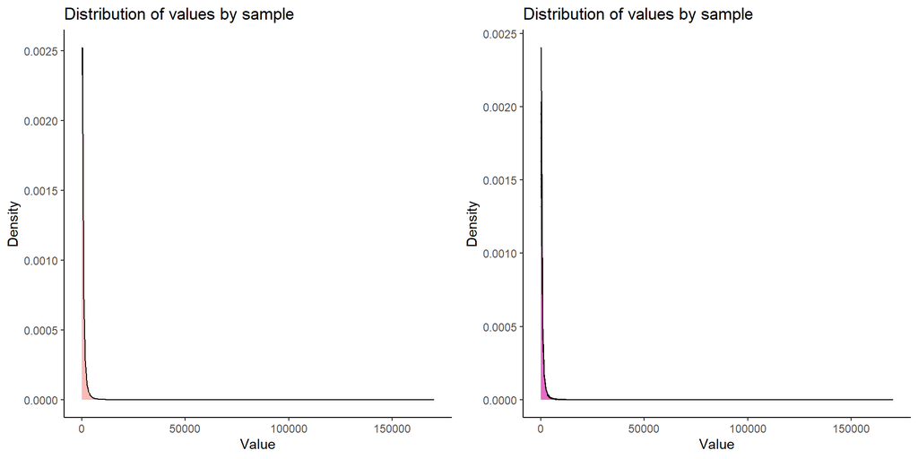

```r
# Density curve and sample densities for raw counts
ggarrange(create_density_curve(x_filt$counts),
          create_density_plot_color(x_filt$counts),
          ncol = 2, nrow = 1,
          labels = NULL,
          font.label = list(size = 4, color = "black", face = "bold"))
```

The previous plot contains count outliers (abnormally high counts) which make it difficult to see the distribution of counts near zero. We replot with `xlim` set to `200`.

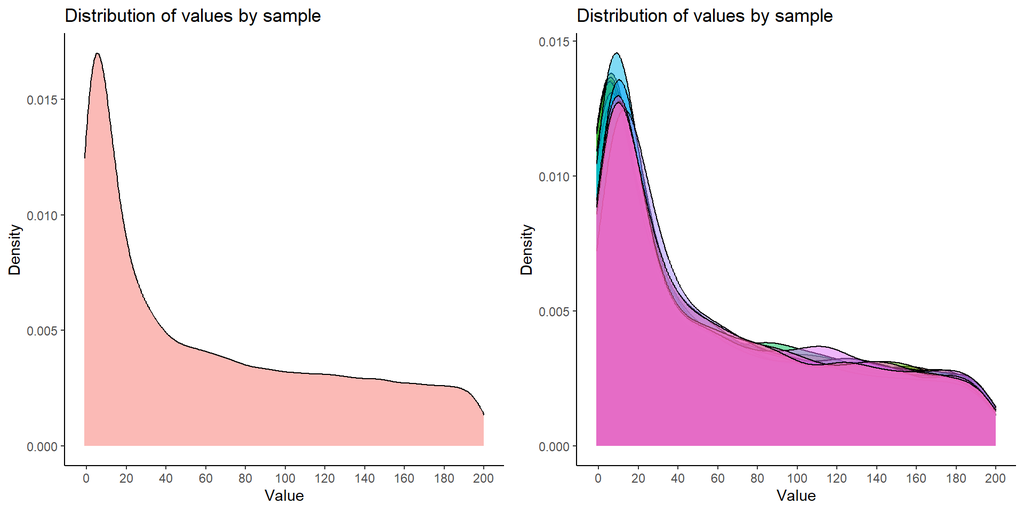

```r
# Density curve and sample densities for raw counts
ggarrange(create_density_curve(x_filt$counts)+
  scale_x_continuous(limits = c(-1, 200), breaks = seq(0, 200, 20)),
          create_density_plot_color(x_filt$counts)+
  scale_x_continuous(limits = c(-1, 200), breaks = seq(0, 200, 20)),
          ncol = 2, nrow = 1,
          labels = NULL,
          font.label = list(size = 4, color = "black", face = "bold"))
```

Now we produce the same figures for the `log2(tpm+1)` data:

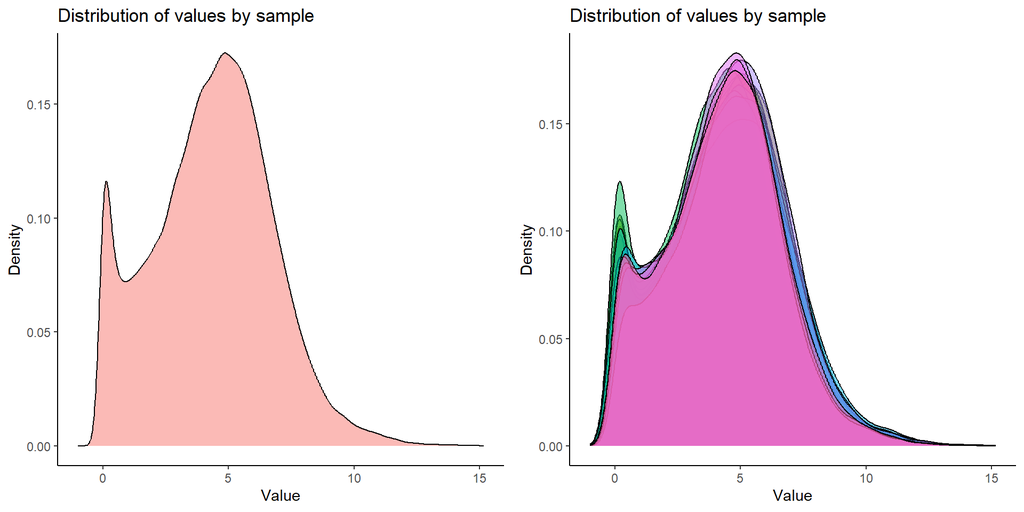

```r
# Density curve and sample densities for raw counts
ggarrange(create_density_curve(log2tpm),
          create_density_plot_color(log2tpm),
          ncol = 2, nrow = 1,
          labels = NULL,
          font.label = list(size = 4, color = "black", face = "bold"))
```

## Count data transformations

Two common count data transformations in the `DESeq2` package are the variance-stabilizing transformation (`vst`) and the regularized logarithm transformation (`rlog`). The point of these two transformations is to remove the dependence of the variance on the mean, particularly the high variance of the logarithm of count data when the mean is low. Both VST and rlog use the experiment-wide trend of variance over mean, in order to transform the data to remove the experiment-wide trend. Note that it is neither required nor desired that all the genes have exactly the same variance after transformation.

The VST is a technique to stabilize the variance across the range of count data in RNA-seq analysis. It is based on the properties of the negative binomial distribution which is often used to model RNA-seq count data. When `fitType="parametric"` is used, the dispersion-mean relationship is modeled as a parametric curve. This transformation aims to stabilize the variance across the range of count data. It helps to normalize the data in such a way that for large counts, the transformation becomes asymptotically equal to the logarithm (base 2) of normalized counts. The full mathematical process for the default case (`fitType="parametric"`) [here](https://github.com/mikelove/DESeq2/blob/devel/inst/script/vst.pdf).

The function `rlog()`, stands for regularized log, transforms the original count data to the log2 scale by fitting a model with a term for each sample and a prior distribution on the coefficients which is estimated from the data. The resulting data contains elements defined as:
$$\log_2(q_{ij}) = \beta_{i0} +
\beta_{ij}$$
where $q_{ij}$ is a parameter proportional to the expected true concentration of fragments for gene $i$ and sample $j$, $β_{i0}$ is an intercept which does not undergo shrinkage, and $β_{ij}$ is the sample-specific effect which is shrunk toward zero based on the dispersion-mean trend over the entire dataset. The trend typically captures high dispersions for low counts, and therefore these genes exhibit higher shrinkage from the `rlog()`. In conclusion, `rlog()` works in a way which minimizes differences between samples for rows with small counts, and which normalizes with respect to library size. The rlog transformation produces a similar variance stabilizing effect as `vst()`, though `rlog()` is more robust in the case when the size factors vary widely. However, it is slower than `vst()`, which may be important for big sample sizes.

```r
# VST and rlog transformations
vsd = vst(dds, blind = FALSE)
rld = rlog(dds, blind = FALSE)
```

See [here](https://bioconductor.org/packages/release/bioc/vignettes/DESeq2/inst/doc/DESeq2.html#data-transformations-and-visualization) for why we set `blind = FALSE`.

We now proceed by estimating size factors and producing mean - sd ($\sqrt{var}$) plots for three different transformations: $\log_2(counts + 1)$, $\text{vst}(counts)$ and $\text{rlog}(counts)$.

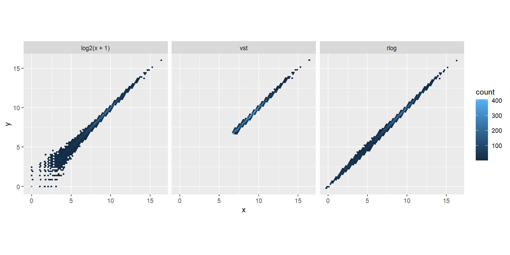

```r
dds = estimateSizeFactors(dds)

# Create folder for mean-variance plots and exploratory heatmaps
if (!dir.exists("MEL_exploratory_plots/Transformations_and_heatmaps")) {
  dir.create("MEL_exploratory_plots/Transformations_and_heatmaps")
}

# Produce a scatter plot of transformed counts for the first two samples
df = bind_rows(
  as.data.frame(log2(counts(dds, normalized=TRUE)[, 1:2]+1)) %>%
    mutate(transformation = "log2(x + 1)"),
  as.data.frame(assay(vsd)[, 1:2]) %>% mutate(transformation = "vst"),
  as.data.frame(assay(rld)[, 1:2]) %>% mutate(transformation = "rlog"))

colnames(df)[1:2] <- c("x", "y")

lvls = c("log2(x + 1)", "vst", "rlog")
df$transformation = factor(df$transformation, levels=lvls)

ggplot(df, aes(x = x, y = y)) + geom_hex(bins = 80) +
  coord_fixed() + facet_grid( . ~ transformation)
```

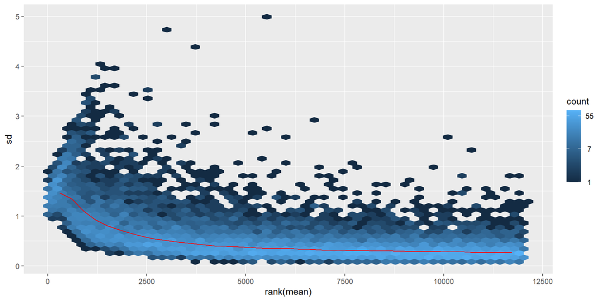

```r
# Produce mean - sd plots
ntd = normTransform(dds) # log2(counts + 1) transformation
plot1 = meanSdPlot(assay(ntd))$gg + rremove("ylab") + rremove("xlab") +
  ggtitle(bquote(bold("log2(counts + 1)"))) +
  theme(plot.title = element_text(hjust = 0.5, vjust = 0.5))
```

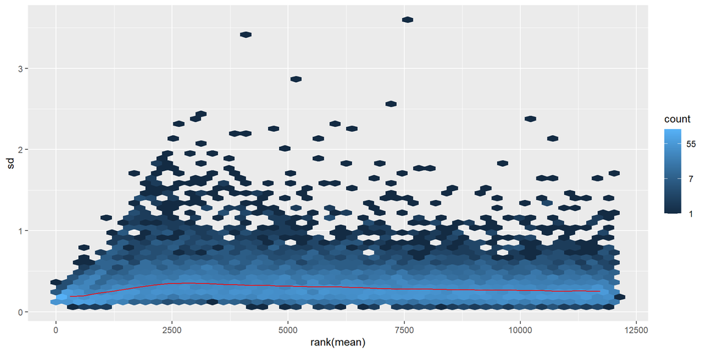

```r
plot2 = meanSdPlot(assay(rld))$gg + rremove("ylab") + rremove("xlab") +
  ggtitle(bquote(bold("rlog"))) +
  theme(plot.title = element_text(hjust = 0.5, vjust = 0.5))
```

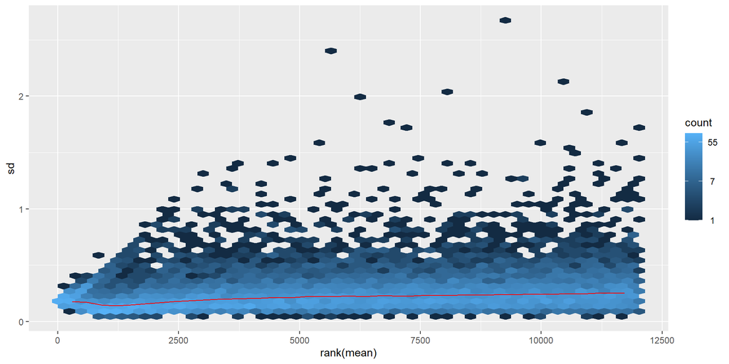

```r
plot3 = meanSdPlot(assay(vsd))$gg + rremove("ylab") + rremove("xlab") +
  ggtitle(bquote(bold("vst"))) +
  theme(plot.title = element_text(hjust = 0.5, vjust = 0.5))
```

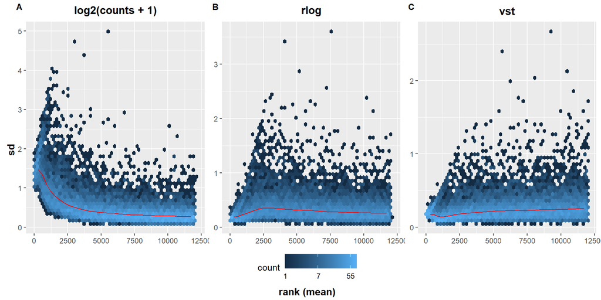

```r
# Use ggarrange to align the three plots horizontally and set the x-axis and y-axis labels
fig = ggarrange(plot1, plot2, plot3,
                ncol = 3, nrow = 1,
                common.legend = TRUE, legend = "bottom",
                labels = c("A", "B", "C"),
                align = "hv",
                font.label = list(size = 10, color = "black", face = "bold", family = NULL, position = "top"))
annotate_figure(fig, left = textGrob(bquote(bold("sd")), rot = 90, vjust = 1, gp = gpar(cex = 1)),
                bottom = textGrob(bquote(bold("rank (mean)")), gp = gpar(cex = 1)))
```